# Wuhan-Hu-1 predictor

Sayantan Ghosh

2020/12/31

# Introduction:

The goal of our Covid Project is to show that the poor countries i.e countries with low per capita income is seen to be not affected by Covid unlike the rich countries i.e the countries which have a higher per capita income facing worse effects of Covid.

Function to read the raw CSV files. The files are aggregated to the country level and then converted to long format.

```r
clean_jhd_to_long <- function(df) {
  df_str <- deparse(substitute(df))
  var_str <- substr(df_str, 1, str_length(df_str) - 4)

  df %>% group_by(`Country/Region`) %>%
    filter(`Country/Region` != "Cruise Ship") %>%
    select(-`Province/State`, -Lat, -Long) %>%
    mutate_at(vars(-group_cols()), sum) %>%
    distinct() %>%
    ungroup() %>%
    rename(country = `Country/Region`) %>%
    pivot_longer(
      -country,
      names_to = "date_str",
      values_to = var_str
    ) %>%
    mutate(date = mdy(date_str)) %>%
    select(country, date, !! sym(var_str))
}
```

# CSSEGISandData

Download datasets

```r
confirmed_raw <- read_csv("https://raw.githubusercontent.com/CSSEGISandData/COVID-19/master/csse_covid_19_data/csse_covid_19_time_series/time_series_covid19_confirmed_global.csv")
deaths_raw <- read_csv("https://raw.githubusercontent.com/CSSEGISandData/COVID-19/master/csse_covid_19_data/csse_covid_19_time_series/time_series_covid19_deaths_global.csv")
jh_covid19_data <- clean_jhd_to_long(confirmed_raw) %>%
  full_join(clean_jhd_to_long(deaths_raw))
```

Next, I pull official country level indicators from the UN Statstics Division to get country level identifiers. Merging by country name is messy. I start with a fuzzy matching approach using the {stringdist} package

```r
jhd_countries <- tibble(country = unique(jh_covid19_data$country)) %>% arrange(country)
ctry_ids <- read_html("https://unstats.un.org/unsd/methodology/m49/") %>%
  html_table()
un_m49 <- ctry_ids[[1]]
colnames(un_m49) <- c("country", "un_m49", "iso3c")
# Data merge
ctry_names_dist <- matrix(NA, nrow = nrow(jhd_countries), ncol = nrow(un_m49))
for(i in 1:length(jhd_countries$country)) {
  for(j in 1:length(un_m49$country)) {
    ctry_names_dist[i,j]<-stringdist(tolower(jhd_countries$country[i]),
                                     tolower(un_m49$country[j]))
  }
}
```

This matches most cases well but some cases need to be adjusted by hand. In addition there are two jurisdictions (Kosovo, Taiwan) that cannot be matched as they are no ‘country’ as far as the U.N. Statistics Devision is concerned.

# WATCH OUT:

**The data from JHU is subject to change without notice.** New countries are being added and names/spelling might change.Also, in the long run, the data provided by the UNSD might change.

```r
min_ctry_name_dist <- apply(ctry_names_dist, 1, min)
matched_ctry_names <- NULL
for(i in 1:nrow(jhd_countries)) {
  un_m49_row <- match(min_ctry_name_dist[i], ctry_names_dist[i,])
  if (length(which(ctry_names_dist[i,] %in% min_ctry_name_dist[i])) > 1) un_m49_row <- NA
  matched_ctry_names <- rbind(matched_ctry_names,
                              tibble(
                                jhd_countries_row = i,
                                un_m49_row = un_m49_row,
                                jhd_ctry_name = jhd_countries$country[i],
                                un_m49_name = ifelse(is.na(un_m49_row), NA,
                                                     un_m49$country[un_m49_row])
                              ))
}
# Inspect 'matched_ctry_names' before using the data.
matched_ctry_names$un_m49_row[matched_ctry_names$jhd_ctry_name == "Bolivia"] <- 27
matched_ctry_names$un_m49_row[matched_ctry_names$jhd_ctry_name == "Brunei"] <- 35
matched_ctry_names$un_m49_row[matched_ctry_names$jhd_ctry_name == "Congo (Brazzaville)"] <- 54
matched_ctry_names$un_m49_row[matched_ctry_names$jhd_ctry_name == "Congo (Kinshasa)"] <- 64
matched_ctry_names$un_m49_row[matched_ctry_names$jhd_ctry_name == "East Timor"] <- 222
matched_ctry_names$un_m49_row[matched_ctry_names$jhd_ctry_name == "Iran"] <- 109
matched_ctry_names$un_m49_row[matched_ctry_names$jhd_ctry_name == "Korea, South"] <- 180
matched_ctry_names$un_m49_row[matched_ctry_names$jhd_ctry_name == "Kosovo"] <- NA
matched_ctry_names$un_m49_row[matched_ctry_names$jhd_ctry_name == "Moldova"] <- 181
matched_ctry_names$un_m49_row[matched_ctry_names$jhd_ctry_name == "Russia"] <- 184
matched_ctry_names$un_m49_row[matched_ctry_names$jhd_ctry_name == "Taiwan*"] <- NA
matched_ctry_names$un_m49_row[matched_ctry_names$jhd_ctry_name == "Tanzania"] <- 236
matched_ctry_names$un_m49_row[matched_ctry_names$jhd_ctry_name == "United Kingdom"] <- 235
matched_ctry_names$un_m49_row[matched_ctry_names$jhd_ctry_name == "US"] <- 238
matched_ctry_names$un_m49_row[matched_ctry_names$jhd_ctry_name == "Venezuela"] <- 243
# Last Step: Match country identifier data
jhd_countries %>%
  left_join(matched_ctry_names %>%
              select(jhd_ctry_name, un_m49_row),
            by = c(country = "jhd_ctry_name")) %>%
  left_join(un_m49 %>% mutate(un_m49_row = row_number()), by = "un_m49_row") %>%
  rename(country = country.x) %>%
  select(country, iso3c)  -> jhd_countries
jh_covid19_data <- jh_covid19_data %>% left_join(jhd_countries) %>%
  select(country, iso3c, date, confirmed, deaths)
# we can save the file for future use. not using this approach anymore
# write_csv(jh_covid19_data, sprintf("jh_covid19_data_%s.csv", Sys.Date()))
```

# worldbank data

Merge Covid data with Worldbank data for GDP and population details. Then convert year format for proper plotting and add other relevant columns.

```r
pull_worldbank_data <- function(vars) {
  new_cache <- wbcache()
  all_vars <- as.character(unique(new_cache$indicators$indicatorID))
  data_wide <- wb(indicator = vars, mrv = 10, return_wide = TRUE)
  new_cache$indicators[new_cache$indicators[,"indicatorID"] %in% vars, ] %>%
    rename(var_name = indicatorID) %>%
    mutate(var_def = paste(indicator, "\nNote:",
                           indicatorDesc, "\nSource:", sourceOrg)) %>%
    select(var_name, var_def) -> wb_data_def
  new_cache$countries %>%
    select(iso3c, iso2c, country, region, income) -> ctries
  left_join(data_wide, ctries, by = "iso3c") %>%
    rename(year = date,
           iso2c = iso2c.y,
           country = country.y) %>%
    select(iso3c, iso2c, country, region, income, everything()) %>%
    select(-iso2c.x, -country.x) %>%
    filter(!is.na(NY.GDP.PCAP.KD),
           region != "Aggregates") -> wb_data
  wb_data$year <- as.numeric(wb_data$year)
  wb_data_def<- left_join(data.frame(var_name = names(wb_data),
                                     stringsAsFactors = FALSE),
                          wb_data_def, by = "var_name")
  wb_data_def$var_def[1:6] <- c(
    "Three letter ISO country code as used by World Bank",
    "Two letter ISO country code as used by World Bank",
    "Country name as used by World Bank",
    "World Bank regional country classification",
    "World Bank income group classification",
    "Calendar year of observation"
  )
  wb_data_def$type = c("cs_id", rep("factor",  4), "ts_id",
                       rep("numeric", ncol(wb_data) - 6))
  return(list(wb_data, wb_data_def))
}
# define population and locality variables
vars <- c("SP.POP.TOTL", "AG.LND.TOTL.K2", "EN.POP.DNST", "EN.URB.LCTY", "SP.DYN.LE00.IN", "NY.GDP.PCAP.KD")
# then use them in wb_list
wb_list <- pull_worldbank_data(vars)
wb_data <- wb_list[[1]]
wb_data_def <- wb_list[[2]]
# summarize wordbank data to get country wise details.
wb_data %>%
  group_by(iso3c) %>%
  arrange(iso3c, year) %>%
  summarise(
    population = last(na.omit(SP.POP.TOTL)),
    land_area_skm = last(na.omit(AG.LND.TOTL.K2)),
    pop_density = last(na.omit(EN.POP.DNST)),
    pop_largest_city = last(na.omit(EN.URB.LCTY)),
    gdp_capita = last(na.omit(NY.GDP.PCAP.KD)),
    life_expectancy = last(na.omit(SP.DYN.LE00.IN))
  ) %>% left_join(wb_data %>% select(iso3c, region, income) %>% distinct()) -> wb_cs
# write_csv(wb_cs, "jh_add_wbank_data.csv")
```

I define event time zero where, for a given country, the confirmed cases match or exceed the Chinese case number at the beginning of the data so that all countries can be compared across event time. Also a require each country to have at least 7 days post event day 0.

```r
dta <- jh_covid19_data %>% mutate(date = ymd(date))
# Time event zero
dta %>%
  group_by(country) %>%
  filter(confirmed >= min(dta$confirmed[dta$country == "China"])) %>%
  summarise(edate_confirmed = min(date)) -> edates_confirmed
# extract significant values and add a column for per hundred thousand population
dta %>%
  left_join(edates_confirmed, by = "country") %>%
  mutate(
    edate_confirmed = as.numeric(date - edate_confirmed)
  ) %>%
  filter(edate_confirmed >= 0) %>%
  group_by(country) %>%
  filter (n() >= 7) %>%
  ungroup() %>%
  left_join(wb_cs, by = "iso3c") %>%
  mutate(
    confirmed_1e5pop = 1e5*confirmed/population
  ) -> df
```

Data as provided by Johns Hopkins University Center for Systems Science and Engineering (JHU CSSE) The sample is limited to countries with at least seven days of positive event days data.

```r
lab_notes <- paste0(
  "Data as provided by Johns Hopkins University Center for Systems Science ",
  "and Engineering (JHU CSSE)\nand obtained on March 23, 2020. ",
  "The sample is limited to countries with at least seven days of positive\n",
  "event days data."
)
lab_x_axis_confirmed <- sprintf(paste(
  "Days since confirmed cases matched or exceeded\n",
  "initial value reported for China (%d cases)\n"
), min(dta$confirmed[dta$country == "China"]))
gg_my_blob <- list(
  scale_y_continuous(trans='log10', labels = scales::comma),
  theme_minimal(),
  theme(
    #plot.title.position = "plot",
    #plot.caption.position =  "plot",
    plot.caption = element_text(hjust = 0),
    axis.title.x = element_text(hjust = 1),
    axis.title.y = element_text(hjust = 1),
  ),
  labs(caption = lab_notes,
       x = lab_x_axis_confirmed,
       y = "Confirmed cases (logarithmic scale)"),
  gghighlight(TRUE,  label_key = country, use_direct_label = TRUE,
              label_params = list(segment.color = NA, nudge_x = 1))
)
```

The base plot confirmed cases per 100,000 inhabitants generated for a representative sample of countries.

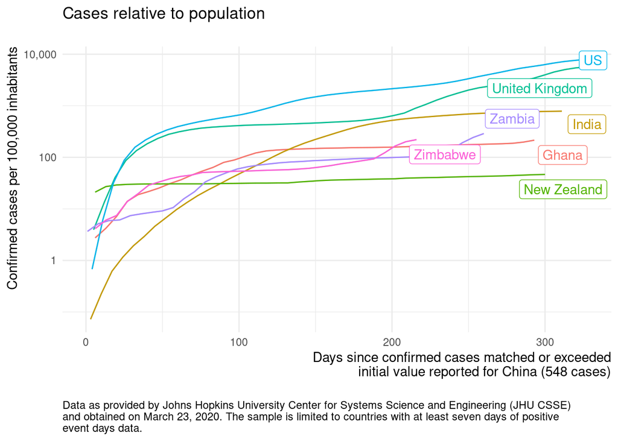

```r
ggplot(df %>% filter (country == c("US","United Kingdom","New Zealand","India","Ghana","Zambia","Zimbabwe")),
       aes(x = edate_confirmed, color = country, y = confirmed_1e5pop)) +
  geom_line() +
  gg_my_blob +
  labs(
    y = "Confirmed cases per 100,000 inhabitants",
    title = "Cases relative to population\n"
  )
```

Clean the data

```r
df_clean = na.omit(df)
view(df_clean)
```

Dataset partition creation

```r
set.seed(1, sample.kind = "Rounding")
# WARNING: in set.seed(1, sample.kind = "Rounding"): non-uniform ’Rounding’ sampler used
test_index <- createDataPartition(y = df_clean$income,
times = 1, p = 0.1, list = FALSE)
edx <- df_clean[-test_index,]
temp <- df_clean[test_index,]
validation <- temp %>%
semi_join(edx, by = "iso3c") %>%
semi_join(edx, by = "confirmed_1e5pop")
removed <- anti_join(temp, validation)
edx <- rbind(edx, removed)
```

```r
rm(test_index, temp, removed)
```

```r
set.seed(1, sample.kind="Rounding")
test_index <- createDataPartition(y = edx$income, times = 1, p = 0.1, list = FALSE)
train_set <- edx[-test_index,]
temp <- edx[test_index,]
test_set <- temp %>%
  semi_join(train_set, by="iso3c") %>%
  semi_join(train_set, by="confirmed_1e5pop")
removed <- anti_join(temp, test_set)
train_set <- anti_join(temp, removed)
train_set <- rbind(train_set, removed)
```

```r
rm(test_index, temp, removed)
```